## Introduction - Clustering to find Mystery in History

The Federalist Papers were a series of 85 essays in which Hamilton authored 51, Madison authored 15, Hamilton and Madison co-authored 3, Jay authored 5 and then there were 11 unidentified that both Hamilton (before his death) and Madison claimed authorship.

The purpose of this assignment is to use cluster analysis to find out who was the author behind the disputed essays, Madison or Hamilton?

### Loading Libraries

```r
#Load all nessessary libraries
# The following function will check if the package is in your library,
# if not then it will install the package from the repository and then load it

EnsurePackage <- function(x) {
  x <- as.character(x)
  if (!require(x,character.only = T))
    install.packages(x,repos = "https://cran.cnr.berkeley.edu/")
  require(x,character.only = T)

}

EnsurePackage("ggplot2") # Create graphics and charts
EnsurePackage("tidyverse") #Data wrangling
EnsurePackage("factoextra") #extract and visualize the output of exploratory multivariate data analyses
EnsurePackage("purrr") #Create elbow method to find optimal clusters
```

### Loading File

The fedpapers85.csv file contains a list of essays with author names and scaled frequency of function words. I have loaded the csv file with rownames as null because I want to replace the number with text that will help me identify essays better when we visualize the cluster

After looking into the dataset we observe that there are 3 Authors Hamilton, Madison and Jay. Some of the essays have been marked as co-written and disputed. Lets visualize the dataset to learn more about it.

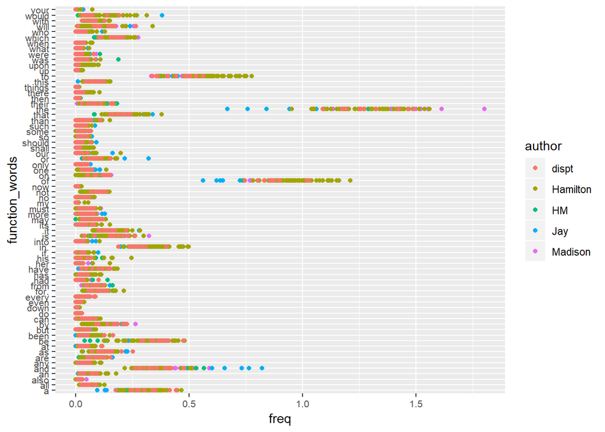

From the graph,we quickly observe that Jay’s essays are very distinctive. Disputed essays have a lot of overlap with Hamilton’s and madison’s essay, making it difficult to interpret.Clustering would help us identify where the disputed essays fall.

Since clustering techniques only work on numerical values we will have to get rid of strings in the data.

### K means - Creating elbow plot to find recommended clusters

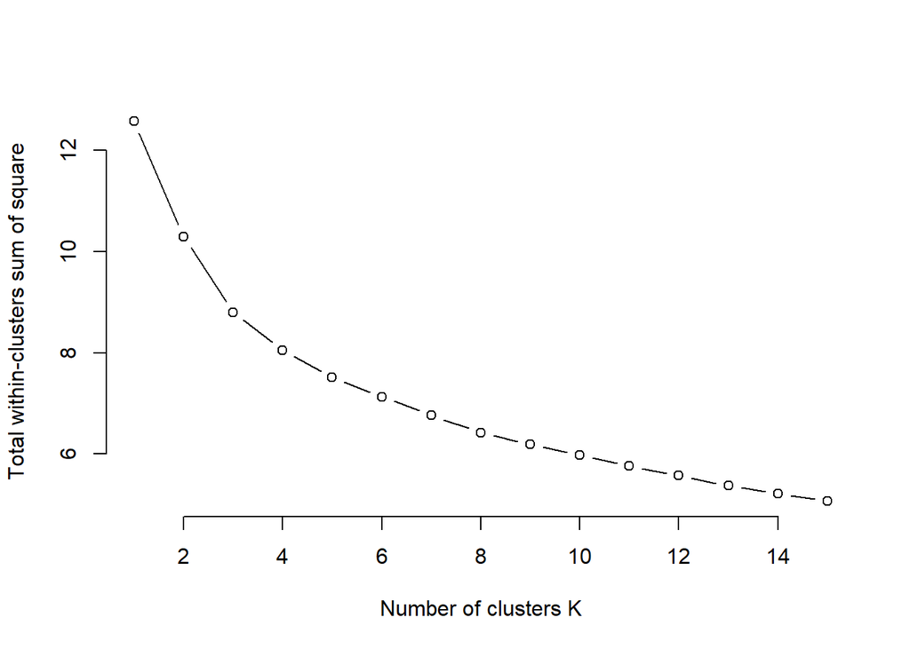

### K means - Clustering

```r
set.seed(8)
km_output <- kmeans(fed_papers_num,centers=5,nstart = 25,iter.max = 100,
                    algorithm = "Hartigan-Wong")
str(km_output)
```

```
## List of 9
##  $ cluster     : Named int [1:85] 1 2 1 1 2 1 4 2 1 4 ...
##   ..- attr(*, "names")= chr [1:85] "di 49." "di 50." "di 51." "di 52." ...
##  $ centers     : num [1:5, 1:70] 0.259 0.28 0.16 0.343 0.299 ...
##   ..- attr(*, "dimnames")=List of 2
##   .. ..$ : chr [1:5] "1" "2" "3" "4" ...
##   .. ..$ : chr [1:70] "a" "all" "also" "an" ...
##  $ totss       : num 12.6
##  $ withinss    : num [1:5] 1.048 1.509 0.599 2.021 2.331
##  $ tot.withinss: num 7.51
##  $ betweenss   : num 5.07
##  $ size        : int [1:5] 13 17 5 24 26
##  $ iter        : int 3
##  $ ifault      : int 0
##  - attr(*, "class")= chr "kmeans"
```

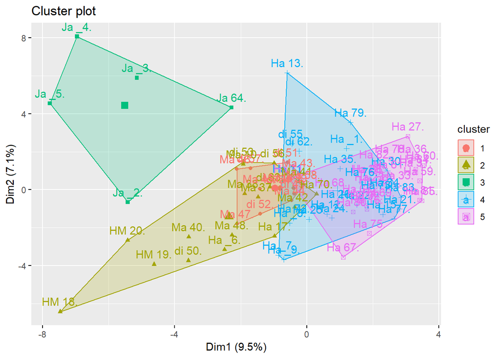

```r
#Visualizing cluster
fviz_cluster(km_output,data = fed_papers_num)
```

From the visualization we can see that the essays authored by Jay have their own clusters, rest all clusters are overlapping. Let create a table to find which essay belongs to which cluster

```r
#Creating a author-cluster table to know which paper belongs to which cluster
table(km_output$cluster,fed_papers$author)
```

```
##
##     dispt Hamilton HM Jay Madison
##   1     5        0  0   0       8
##   2     4        3  3   0       7
##   3     0        0  0   5       0
##   4     2       22  0   0       0
##   5     0       26  0   0       0
```

```r
km_output$cluster
```

```
## di 49. di 50. di 51. di 52. di 53. di 54. di 55. di 56. di 57. di 62.
##      1      2      1      1      2      1      4      2      1      4
## di 63. Ha _1. Ha 11. Ha 12. Ha 13. Ha 15. Ha 16. Ha 17. Ha 21. Ha 22.
##      2      4      4      4      4      4      5      2      4      4
## Ha 23. Ha 24. Ha 25. Ha 26. Ha 27. Ha 28. Ha 29. Ha 30. Ha 31. Ha 32.
##      5      4      4      4      5      5      5      4      5      5
## Ha 33. Ha 34. Ha 35. Ha 36. Ha 59. Ha _6. Ha 60. Ha 61. Ha 65. Ha 66.
##      5      4      4      5      5      2      5      5      5      5
## Ha 67. Ha 68. Ha 69. Ha _7. Ha 70. Ha 71. Ha 72. Ha 73. Ha 74. Ha 75.
##      5      5      5      4      2      5      4      4      5      5
## Ha 76. Ha 77. Ha 78. Ha 79. Ha _8. Ha 80. Ha 81. Ha 82. Ha 83. Ha 84.
##      4      4      5      4      4      5      5      5      4      5
## Ha 85. Ha _9. HM 18. HM 19. HM 20. Ja _2. Ja _3. Ja _4. Ja _5. Ja 64.
##      5      4      2      2      2      3      3      3      3      3
## Ma 10. Ma 14. Ma 37. Ma 38. Ma 39. Ma 40. Ma 41. Ma 42. Ma 43. Ma 44.
##      2      1      2      2      1      2      2      2      1      1
## Ma 45. Ma 46. Ma 47. Ma 48. Ma 58.
##      1      1      1      2      1
```

### Analyzing Attribute Importance

To find out which attributes contributed the most we will use coefficient of variance to measure the spread of each attribute on the clusters. The more the variance the greater the spread and the more important the feature is in distinguishing between the authors.

```r
#Analyzing which attributes are most useful
km_output$centers
```

```
##           a        all        also         an       and        any
## 1 0.2590000 0.05815385 0.012076923 0.05046154 0.3574615 0.03469231
## 2 0.2796471 0.05211765 0.008117647 0.06076471 0.4551765 0.02958824
## 3 0.1598000 0.03600000 0.019800000 0.02520000 0.7152000 0.03760000
## 4 0.3427917 0.05166667 0.004458333 0.07391667 0.3421667 0.04425000
## 5 0.2991538 0.05496154 0.005769231 0.08553846 0.3276923 0.05126923
##          are        as         at        be       been        but
## 1 0.08646154 0.1513077 0.03253846 0.3343077 0.05592308 0.03169231
## 2 0.08058824 0.1110588 0.04029412 0.2301765 0.06858824 0.03258824
## 3 0.08520000 0.1568000 0.03600000 0.2754000 0.02680000 0.04920000
## 4 0.07650000 0.1094167 0.05979167 0.3131667 0.05887500 0.02858333
## 5 0.06903846 0.1266154 0.04000000 0.3248462 0.06276923 0.03265385
##           by        can          do         down        even      every
## 1 0.15769231 0.03200000 0.004846154 0.0019230769 0.010769231 0.03638462
## 2 0.15858824 0.02558824 0.005000000 0.0002352941 0.009411765 0.02094118
```

[output cut: 57 more lines]

```r
km_df <- as.data.frame(km_output$centers) #converting matrix to dataframe

#Calculating the coefficient of variance
100*apply(km_df,2,sd)/colMeans(km_df)
```

```
##          a        all       also         an        and        any
##  25.360367  16.911813  61.471632  39.133281  36.854180  21.419457
##        are         as         at         be       been        but
##   8.900513  16.895778  25.380650  14.502868  29.752980  23.295647
##         by        can         do       down       even      every
##  19.920389  19.178983  22.792753  90.212800  23.576799  50.161385
##       for.       from        had        has       have        her
##   4.232783  12.206077  51.619901  23.180145   4.833536  67.540779
##        his        if.        in.       into         is         it
##  51.273108  44.327635  11.070970  37.975872  21.711880  18.403410
##        its        may       more       must         my         no
##  18.083082  11.028226  38.238925  20.077229  47.622311  35.361782
##        not        now         of         on        one       only
##   8.330557  20.617693  15.124812  41.581232  40.644855  38.753048
##         or        our      shall     should         so       some
##  30.187640  80.787498  25.878254  33.035937  23.482807  26.479774
##       such       than       that        the      their       then
##  34.723849  23.369096  12.356853  20.031286  29.979562  15.210707
##      there     things       this         to         up       upon
##  63.248536  54.372686  21.572756  15.115288 121.786797 113.762974
##        was       were       what       when      which        who
##  45.665216  30.266721  24.922277  39.940799  18.928628  32.157892
##       will       with      would       your
##  19.955592   9.515413  36.493657  93.664429
```

### Clustering using HAC method

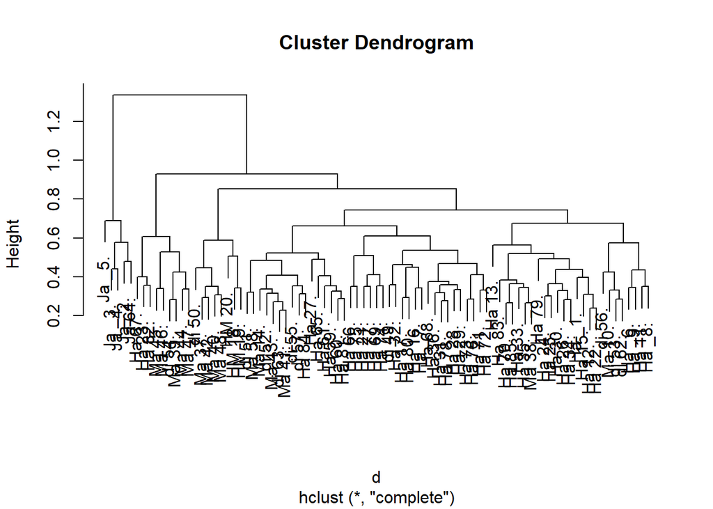

```r
#Measure eucleadian distance between each point
set.seed(8)
d <- dist(as.matrix(fed_papers_num))
hac_output <- hclust(d, method = "complete")
#Plot the dendogram
plot(hac_output)
```

```r
#Based on the plot having 10 cuts would get us a better idea
hac_cut <- cutree(hac_output,10)
table(hac_cut,fed_papers$author)
```

```
##
## hac_cut dispt Hamilton HM Jay Madison
##      1      1       15  0   0       0
##      2      1        0  3   0       4
##      3      5        7  0   0       4
##      4      3        4  0   0       1
##      5      1        0  0   0       5
##      6      0       16  0   0       1
##      7      0        6  0   0       0
##      8      0        3  0   0       0
##      9      0        0  0   4       0
##      10     0        0  0   1       0
```

### Visualizing HAC using Factoextra library function

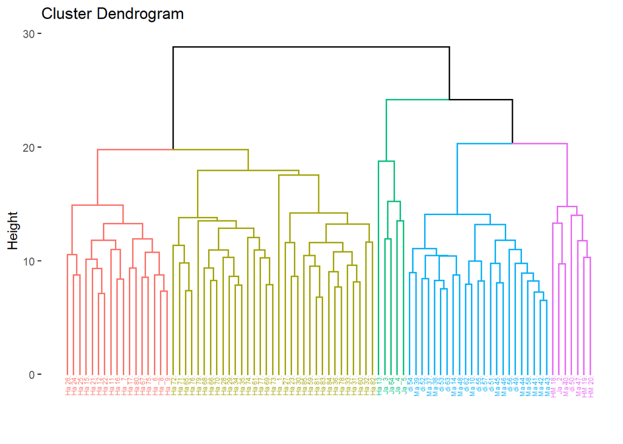

```r
#HAC use desirable clusters after modelling
hac_output <- hcut(fed_papers_num, k = 5, stand = TRUE)
fviz_dend(hac_output,cex = 0.4 )
```